# Unsupervised Learning Assignment 1

This notebook contains all the code for the unsupervised learning assignment 1 implementation of Multidimensional Scaling on the UN_Statistics dataset.

Multidimensional scaling (MDS) is a unsupervised, multivariate data analysis technique that is used to visualize the similarity/dissimilarity between samples by plotting points in two dimensional plots.

MDS represents data in a lower-dimensional space, mapped from a higher dimentional space. In this notebook one and two dimentional representations are generated for a higher dimentional data set.

From an alorithmic perspective, MDS uses a dissimilarity matrix to represent the distances between pairs of objects. The input data to the MDS algorithm is this disimilarity matrix.

# Enviroment Setup and Import data files

This notebook is set up to make the results atained as reproducable as posible.

```r
#setup work space, install packages and import libs
rm(list=ls())
suppressMessages(library(cluster))
suppressMessages(library(MASS))
suppressMessages(library(smacof))
suppressMessages(library(magrittr))
suppressMessages(library(dplyr))
suppressMessages(library(ggpubr))
suppressMessages(library(psych))

#import and sample data, apply seed and sample to get the set of 400 unique data points
statistics <- read.csv("UN_Statistics.csv")
X <- as.matrix(statistics[,-1])
rownames(X) <- statistics[,1]
```

#data exploration

```r
rownames(X)
```

```
##  [1] "Albania"          "Argentina"        "Australia"
##  [4] "Austria"          "Benin"            "Boliva"
##  [7] "Brazil"           "Cambodia"         "China"
## [10] "Colombia"         "Croatia"          "El Salvador"
## [13] "France"           "Greece"           "Guatemala"
## [16] "Iran"             "Italy"            "Malawi"
## [19] "Netherlands"      "Pakistan"         "Papua new Guinea"
## [22] "Peru"             "Romania"          "USA"
## [25] "Zimbabwe"
```

```r
sapply(statistics,class)
```

```
##   Country  Increase      Life       IMR       TFR       GDP
##  "factor" "numeric" "numeric" "integer" "numeric" "numeric"
```

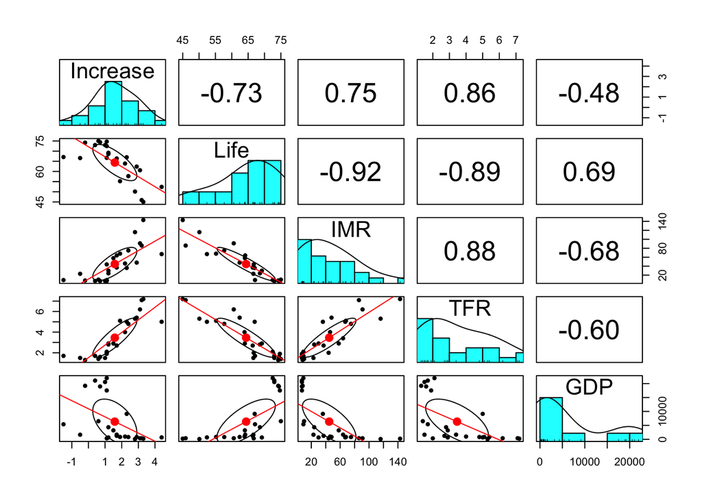

```r
pairs.panels(statistics[,-1],cex=1,lm=TRUE)
```

# Classical MDS Scaling

First let’s plot the data before we normalize it.

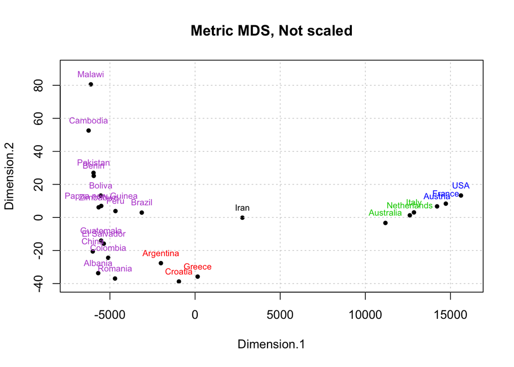

```r
d <- dist(X) # euclidean distances between the rows

#preform clustering so we can allocate colours to the plot
cluster <- hclust(d,method="complete")
clusvec <- cutree(cluster, k=5)

scaledDistances <- cmdscale(d) # preform the multidimensional scalling

# create empty plot and then add text and colours. Colours added based on the clustor groups
plot (scaledDistances, xlab="Dimension.1", ylab="Dimension.2",
  main="Metric MDS, Not scaled", type="p", pch=20,ylim = c(-40,90), xlim = c(-7000,16000))
grid()
#ensure you list enough colours for the number of clusters
colvec <- c("mediumorchid",
            "red",
            "green3",
            "blue",
            "black",
            "gold",
            "indianred",
            "moccasin",
            "lightcyan",
            "skyblue")
for (i in 1:length(scaledDistances[,1]))
  text (scaledDistances[i,1],
        scaledDistances[i,2],
        rownames(X)[i],
        col=colvec[clusvec[i]],
        cex=0.7,
        pos = 3)
```

#Normalized MDS Next we can repeat the process but this time normalize the data scaling

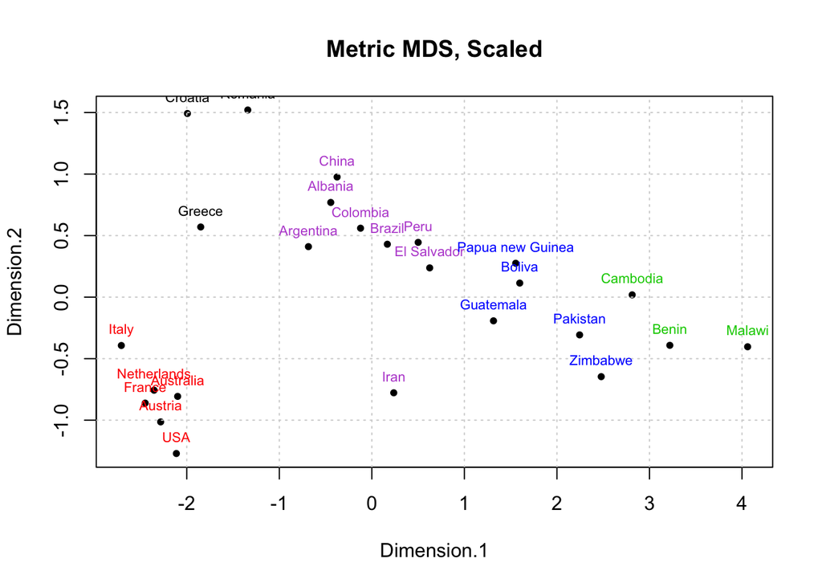

```r
# euclidean distances between the rows
d <- dist(scale(X, center=TRUE, scale=TRUE), method="euclidean")

#preform clustering so we can allocate colours to the plot
cluster <- hclust(d,method="complete")
clusvec <- cutree(cluster, k=5)

scaledDistances <- cmdscale(d, k = 2) # preform the multidimensional scalling

# create empty plot and then add text and colours. Colours added based on the clustor groups
plot (scaledDistances, xlab="Dimension.1", ylab="Dimension.2",
  main="Metric MDS, Scaled", type="p", pch=20)
grid()
for (i in 1:length(scaledDistances[,1]))
  text (scaledDistances[i,1],
        scaledDistances[i,2],
        rownames(X)[i],
        col=colvec[clusvec[i]],
        cex=0.7,
        pos = 3)
```

#One Dimentional Plot Generate a one dimentional representation of the data

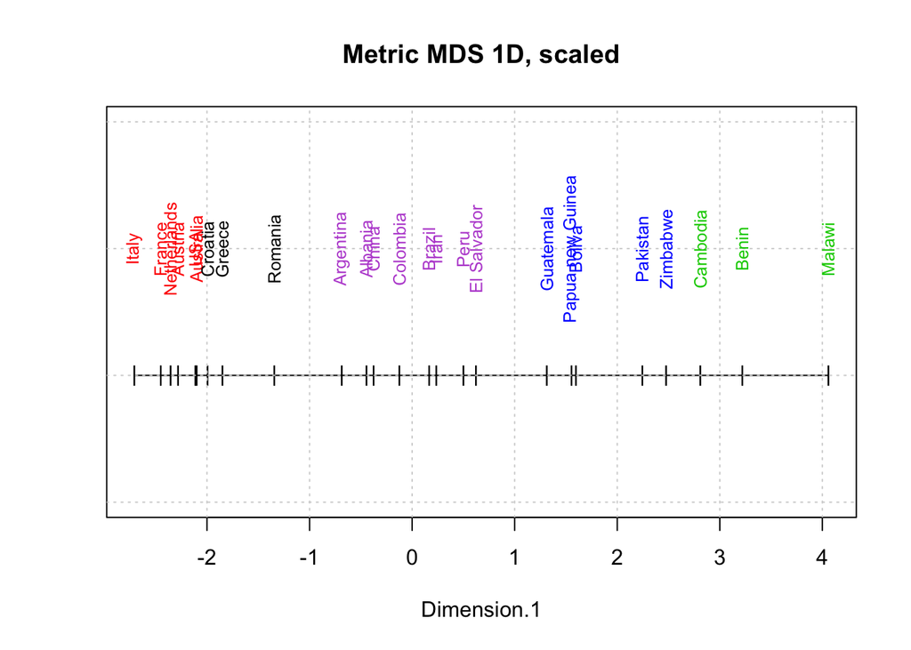

```r
d <- dist(scale(X)) # euclidean distances between the rows

#preform clustering so we can allocate colours to the plot
cluster <- hclust(d,method="complete")
clusvec <- cutree(cluster, k=5)

scaledDistances <- cmdscale(d, eig=TRUE, k=1) # preform the multidimensional scalling

x <- data.frame(scaledDistances$points[,1],1)

# create empty plot and then add text and colours. Colours added based on the clustor groups
plot (x, xlab="Dimension.1",
  main="Metric MDS 1D, scaled",
  type = 'o',
  pch = '|',
  ylab = '',
  yaxt='n',
  xlim=c(min(x),
         max(x)),
  ylim=c(0.95,1.1))
grid()

for (i in 1:length(x[,1]))
  text (x[i,1],
        1.05,
        rownames(X)[i],
        col=colvec[clusvec[i]],
        cex=0.8,
        srt=90)
```

# Classical MDS

```r
# Cmpute MDS
mds <- scale(X) %>%
  dist() %>%
  cmdscale() %>%
  as_tibble()
```

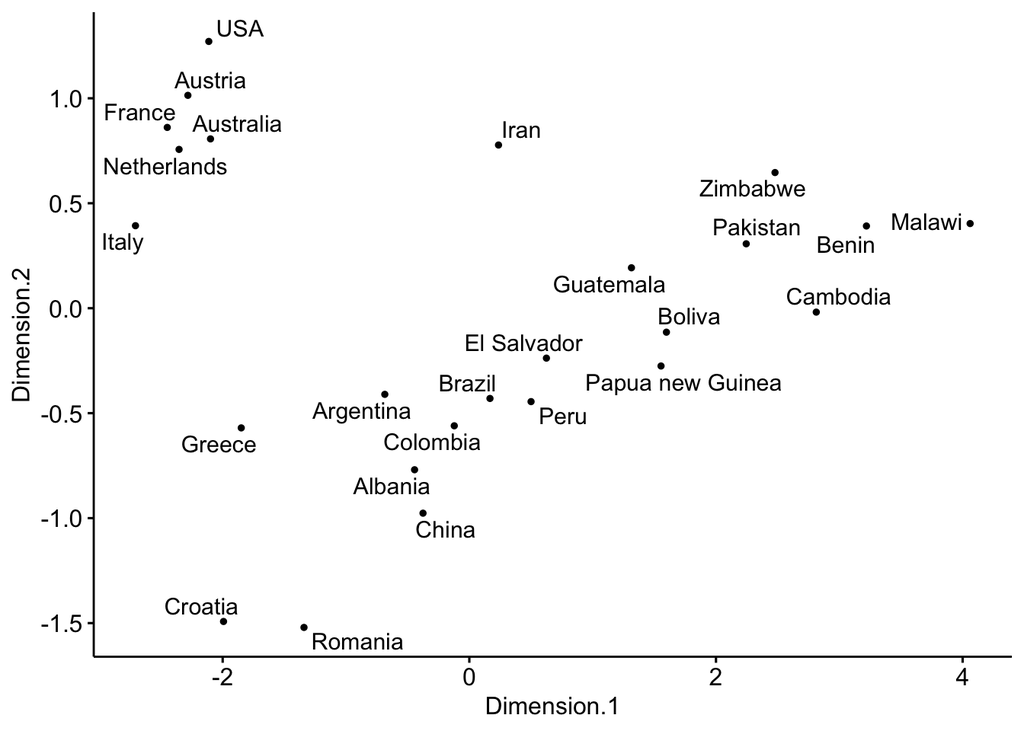

```r
colnames(mds) <- c("Dimension.1", "Dimension.2")
# Plot MDS
mds[,2] <- -1 * mds[,2]
ggscatter(mds, x = "Dimension.1", y = "Dimension.2",
          label = rownames(X),
          size = 1,
          repel = TRUE)
```

We can add colours to the plots while clustering them together

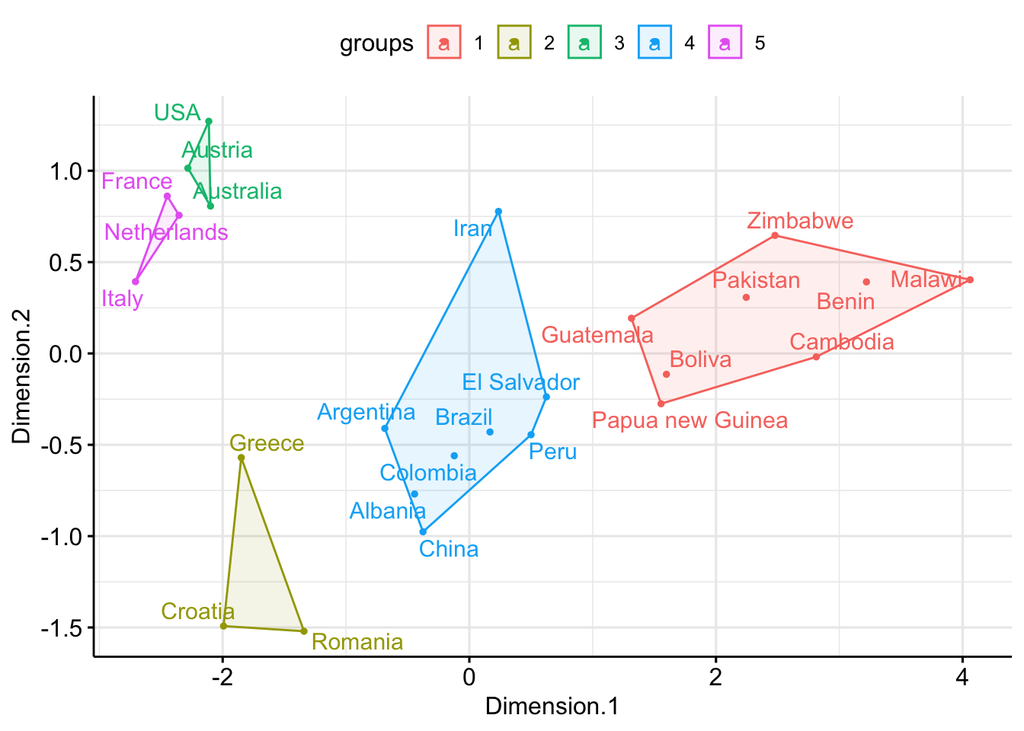

```r
# K-means clustering
clust <- kmeans(mds, 5)$cluster %>%
  as.factor()
mds <- mds %>%
  mutate(groups = clust)
# Plot and color by groups
ggscatter(mds, x = "Dimension.1", y = "Dimension.2",
          label = rownames(X),
          color = "groups",
          palette = "pal3",
          size = 1,
          ellipse = TRUE,
          ellipse.type = "convex",
          repel = TRUE) +
grids(axis = c("xy", "x", "y"), color = "grey92", size = NULL,
  linetype = NULL)
```

# Kruskal’s non-metric multidimensional scaling

```r
mds <- X %>%
  dist() %>%
  isoMDS() %>%
  .$points %>%
  as_tibble()
```

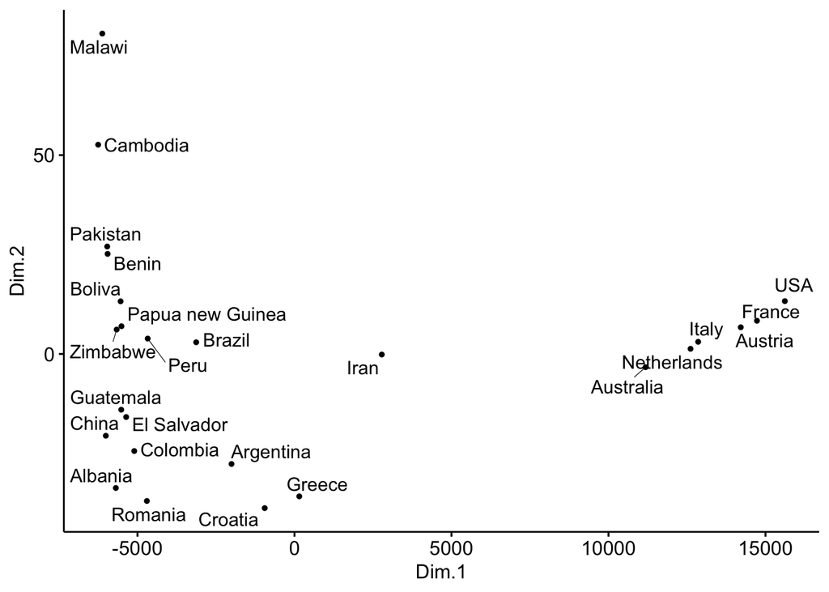

```r
colnames(mds) <- c("Dim.1", "Dim.2")
# Plot MDS
ggscatter(mds, x = "Dim.1", y = "Dim.2",
          label = rownames(X),
          size = 1,
          repel = TRUE)
```

# Sammon’s non-linear mapping:

```r
mds <- scale(X) %>%
  dist() %>%
  sammon() %>%
  .$points %>%
  as_tibble()
```

```
## Initial stress        : 0.01485
## stress after  10 iters: 0.00425, magic = 0.500
## stress after  20 iters: 0.00421, magic = 0.500
```

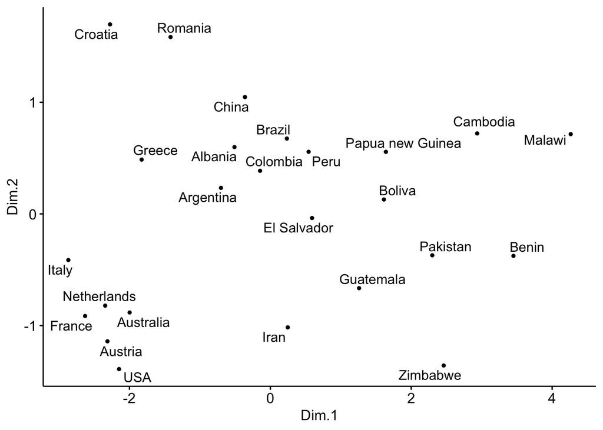

```r
colnames(mds) <- c("Dim.1", "Dim.2")
# Plot MDS
ggscatter(mds, x = "Dim.1", y = "Dim.2",
          label = rownames(X),
          size = 1,
          repel = TRUE)
```

# Visualizing a correlation matrix using Multidimensional Scaling

MDS can be also used to reveal a hidden pattern in a correlation matrix.

Correlation actually measures similarity, but it is easy to transform it to a measure of dissimilarity.

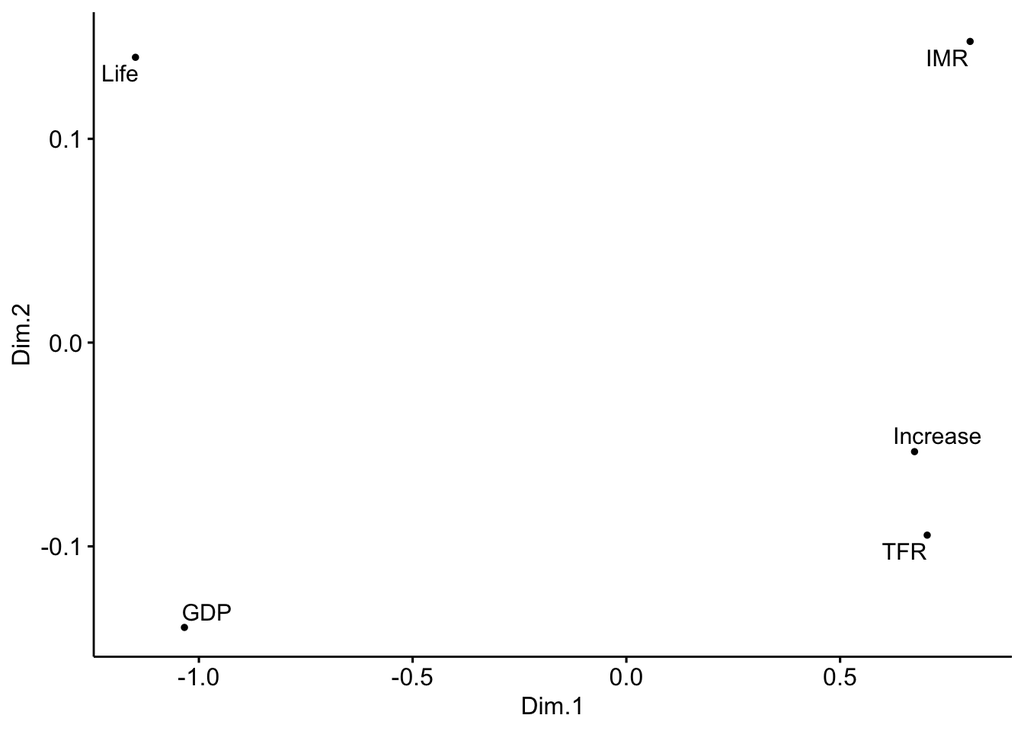

```r
res.cor <- cor(X, method = "spearman")
mds.cor <- (1 - res.cor) %>%
  cmdscale() %>%
  as_tibble()
colnames(mds.cor) <- c("Dim.1", "Dim.2")
ggscatter(mds.cor, x = "Dim.1", y = "Dim.2",
          size = 1,
          label = colnames(res.cor),
          repel = TRUE)
```

# MDS Biplot

Visualize underlying variables along with MDS plot

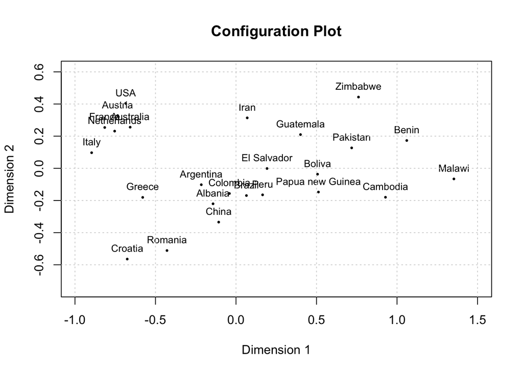

```r
d <- dist(scale(X, center=TRUE, scale=TRUE), method="euclidean")

countriesMds <- mds(delta = d, ndim = 2)
plot(countriesMds)
grid()
```

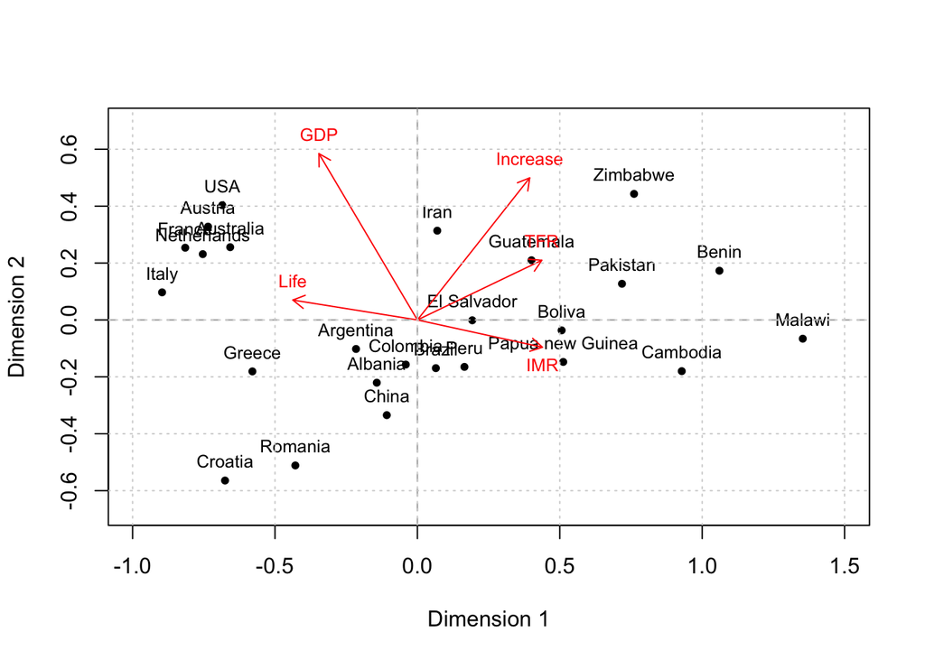

```r
biplot <- biplotmds(countriesMds, extvar = X)
plot(biplot,  vecscale = 0.3, vec.conf = list(col = "red", length = 0.1),main="")
grid()
```